# Income above or below 50k

Mathew Lisec

8/11/2019

### Goal

The purpose of this report is to create a predicter to tell whether or not a person made more or less than 50k per year according to the 1994 census. I will be using the Naive Bayes classifier to make predictions.

### Load Libraries

The following code will load the libraries that will be used in order to create a Naive Bayes classifier.

```r
> library(e1071)
>
> # the following utility files can be found attached to the assignment
> source("https://raw.githubusercontent.com/grbruns/cst383/master/lin-regr-util.R")
> source("https://raw.githubusercontent.com/grbruns/cst383/master/class-util.R")
```

### Reading and preprocessing the data

First, we will preprocess the data. I preprocessed the data to represent a binary approach in order to visualize the data more easily. For race, the categories are “white” and “other,” for education, the categories are “College Grad” and “Not College Grad,” and for age, the categories are “Older than 35” or “Younger than 35.”

```r
> census = read.csv("https://raw.githubusercontent.com/grbruns/cst383/master/1994-census-summary.csv")
> census$label = factor(census$label, labels=c("<=50k", ">50k"))
> census$sex = factor(census$sex, labels=c("female", "male"))
> census$race = factor(ifelse(census$race == "White", "white", "other"))
> census$age = factor(ifelse(census$age >= 35, "Older than 35", "Younger than 35"))
> census$education = factor(ifelse(census$education == "Bachelors" | census$education == "Doctorate" | census$education == "Masters", "College Grad", "Not College Grad"))
```

### Data Exploration

The following graphs represent some of the data found in the census table. I will be using this information to create a naive bayes classifier.

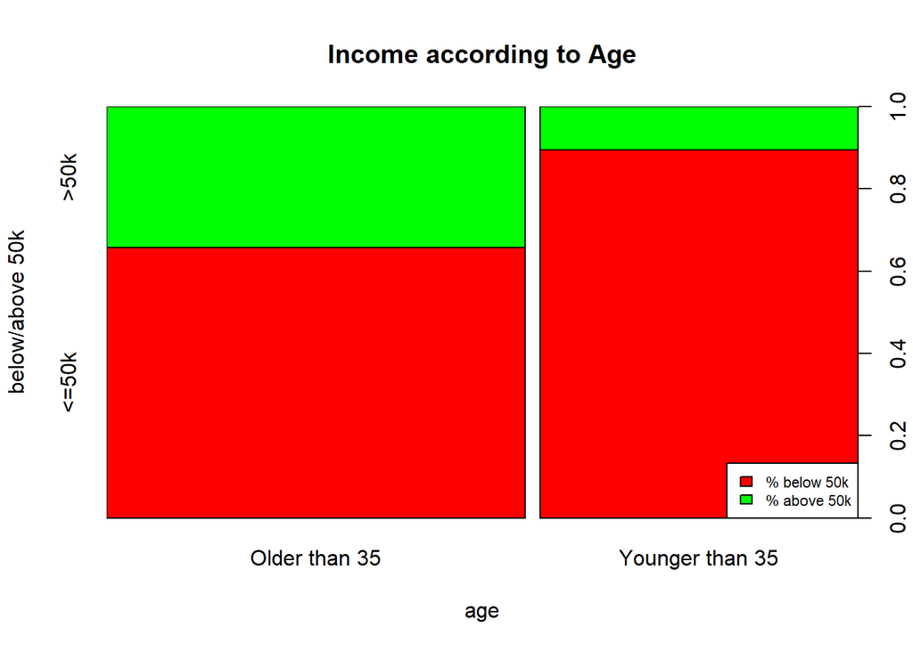

```r
> cols = c("red", "green")
>
> plot(census$age, census$label, col=cols, ylab = "below/above 50k", xlab = "age", main = "Income according to Age")
> legend("bottomright", c("% below 50k", "% above 50k"), cex = 0.7, fill = cols)
```

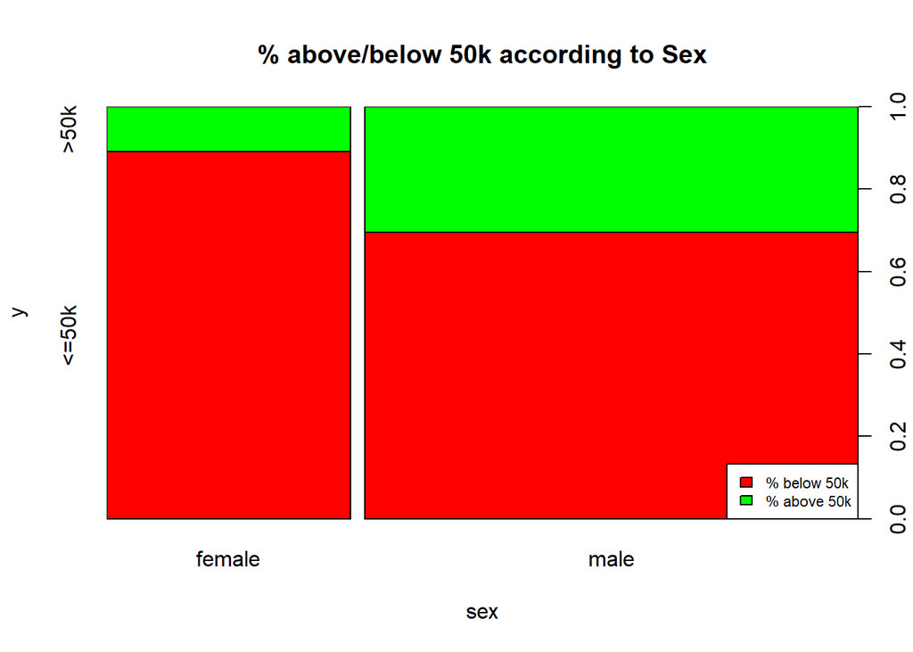

```r
> plot(census$sex, census$label, col=cols, xlab = "sex", main = "% above/below 50k according to Sex")
> legend("bottomright", c("% below 50k", "% above 50k"), cex = 0.7, fill = cols)
```